# TCGA CA20-CJ30 Analysis

Hamda Binte Ajmal

3 May 2019

## Contents

-TCGA Pan Cancer: Cross Correlation between CA and CJ Genes -TCGA Pan Cancer: Cross Correlation b/w CAScore and CJ genes -TCGA Pan Cancer: Cross Correlation table -TCGA Breast Cancer: Cross Correlation between CA and CJ Genes -TCGA Breast Cancer: Cross Correlation b/w CAScore and CJ genes -TCGA Breast Cancer: Cross Correlation table -TCGA Breast Cancer: DE analysis -TCGA Luminal A BC: Cross Correlation between CA and CJ Genes -TCGA Luminal A BC: Cross Correlation b/w CAScore and CJ genes -TCGA Luminal A BC: Cross Correlation table -TCGA Luminal A BC: DE analysis -TCGA Luminal B BC: Cross Correlation between CA and CJ Genes -TCGA Luminal B BC: Cross Correlation b/w CAScore and CJ genes -TCGA Luminal B BC: Cross Correlation table -TCGA Luminal B BC: DE analysis -TCGA Basal BC: Cross Correlation between CA and CJ Genes -TCGA Basal BC: Cross Correlation b/w CAScore and CJ genes -TCGA Basal BC: Cross Correlation table -TCGA Basal BC: DE analysis -TCGA Her2 BC: Cross Correlation between CA and CJ Genes -TCGA Her2 BC: Cross Correlation b/w CAScore and CJ genes -TCGA Her2 BC: Cross Correlation table -TCGA Her2 BC: DE analysis

## Pan Cancer Cross Correlation b/w CA and CJ genes

- Correlation betweenCA20 gene expression and CJ30 Gene expression

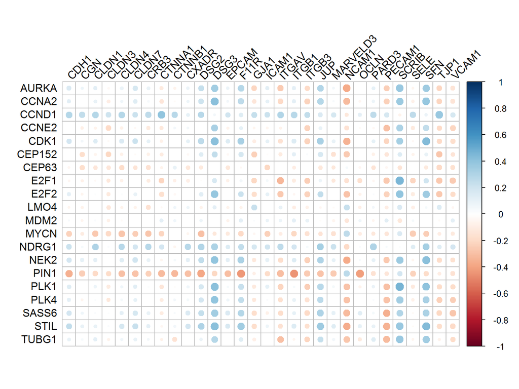

## Pan Cancer Cross Correlation b/w CAScore and CJ genes

- between CA20 Score and expression of each gene in CJ30 across all cancer cohorts

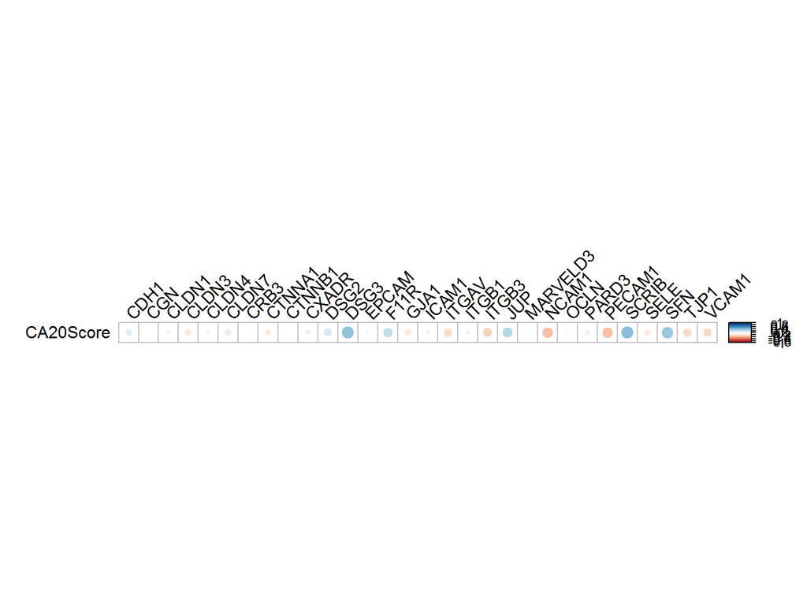

## Pan Cancer Cross Correlation table (CAScore - CJ Genes)

Genes are listed in decreasing order of their correlation with CA20 Score.

Positive Correlation and Negative Correlation

|  | Cor | P-val |
| --- | --- | --- |
| SCRIB | 0.423 | 0.000 |
| DSG3 | 0.409 | 0.000 |
| SFN | 0.370 | 0.000 |
| JUP | 0.282 | 0.000 |
| F11R | 0.249 | 0.000 |
| DSG2 | 0.179 | 0.000 |
| CDH1 | 0.131 | 0.000 |
| CLDN7 | 0.115 | 0.000 |
| CXADR | 0.083 | 0.000 |
| PARD3 | 0.080 | 0.000 |
| ITGB1 | 0.068 | 0.000 |
| CLDN1 | 0.066 | 0.000 |
| ICAM1 | 0.063 | 0.000 |
| CLDN4 | 0.052 | 0.000 |
| EPCAM | 0.049 | 0.000 |
| MARVELD3 | 0.028 | 0.004 |
| CRB3 | 0.014 | 0.167 |
| CTNNB1 | 0.010 | 0.321 |

|  | Cor | P-val |
| --- | --- | --- |
| NCAM1 | -0.300 | 0.000 |
| PECAM1 | -0.296 | 0.000 |
| ITGB3 | -0.226 | 0.000 |
| VCAM1 | -0.202 | 0.000 |
| TJP1 | -0.201 | 0.000 |
| ITGAV | -0.183 | 0.000 |
| GJA1 | -0.119 | 0.000 |
| CLDN3 | -0.118 | 0.000 |
| CTNNA1 | -0.112 | 0.000 |
| SELE | -0.100 | 0.000 |
| OCLN | -0.039 | 0.000 |
| CGN | -0.006 | 0.573 |

## R Breast Cancer Cohort - Cross Correlation b/w CA-CJ genes

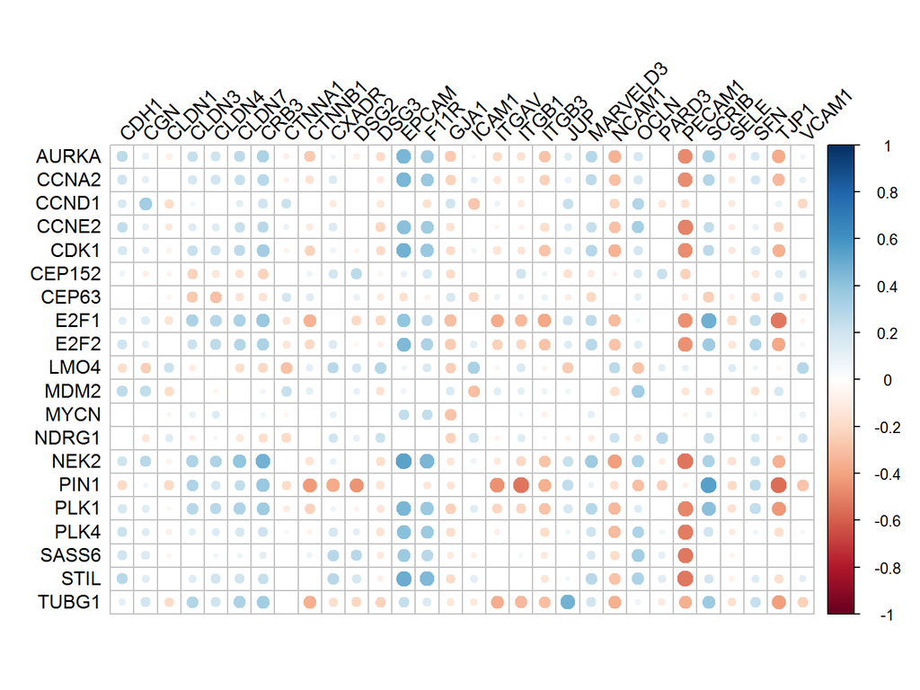

## R Breast Cancer Cohort - Cross Correlation b/w CA20Score-CJ genes

- Correlation of expression of CJ30 genes with CA20Score in breast cancer cohort.

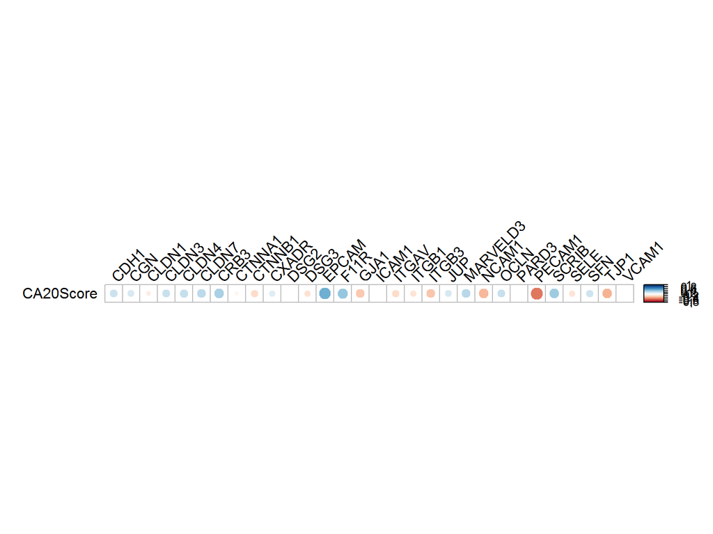

## R Breast Cancer Cohort - Cross Correlation table (CA20Score-CJ genes)

- CJ30 gene expression with CA20 Score

  Positive Correlation and Negative Correlation

  |  | Cor | P-val |
  | --- | --- | --- |
  | EPCAM | 0.483 | 0.000 |
  | F11R | 0.387 | 0.000 |
  | SCRIB | 0.352 | 0.000 |
  | CRB3 | 0.329 | 0.000 |
  | MARVELD3 | 0.278 | 0.000 |
  | CLDN7 | 0.268 | 0.000 |
  | CLDN4 | 0.236 | 0.000 |
  | OCLN | 0.221 | 0.000 |
  | CLDN3 | 0.220 | 0.000 |
  | CDH1 | 0.215 | 0.000 |
  | SFN | 0.200 | 0.000 |
  | JUP | 0.161 | 0.000 |
  | CGN | 0.160 | 0.000 |
  | CXADR | 0.137 | 0.000 |
  | ICAM1 | 0.050 | 0.085 |
  | VCAM1 | 0.034 | 0.230 |
  | PARD3 | 0.020 | 0.491 |

  |  | Cor | P-val |
  | --- | --- | --- |
  | PECAM1 | -0.530 | 0.000 |
  | TJP1 | -0.348 | 0.000 |
  | NCAM1 | -0.329 | 0.000 |
  | ITGB3 | -0.274 | 0.000 |
  | GJA1 | -0.263 | 0.000 |
  | CTNNB1 | -0.186 | 0.000 |
  | ITGAV | -0.182 | 0.000 |
  | DSG3 | -0.155 | 0.000 |
  | ITGB1 | -0.145 | 0.000 |
  | SELE | -0.142 | 0.000 |
  | CLDN1 | -0.093 | 0.001 |
  | CTNNA1 | -0.056 | 0.050 |
  | DSG2 | -0.004 | 0.887 |

## DE analysys of all BRCA tumor and normal samples

- 1095 tumour samples and 113 normal samples. The results could be biased because of a big difference in number of samples.

```
## I Need about  139 seconds for this Complete Normalization Upper Quantile  [Processing 80k elements /s]
```

```
## Step 1 of 4: newSeqExpressionSet ...
```

```
## Step 2 of 4: withinLaneNormalization ...
```

```
## Step 3 of 4: betweenLaneNormalization ...
```

```
## Step 4 of 4: exprs ...
```

```
## Batch correction skipped since no factors provided
```

```
## ----------------------- DEA -------------------------------
```

```
## there are Cond1 type Tumor in  1095 samples
```

```
## there are Cond2 type Normal in  113 samples
```

```
## there are  9153 features as miRNA or genes
```

```
## I Need about  369 seconds for this DEA. [Processing 30k elements /s]
```

```
## ----------------------- END DEA -------------------------------
```

```
##          mRNA     logFC           FDR     Tumor       Normal      Delta
## CTNNA1 CTNNA1  5.327041 4.609659e-123 10.336986  433.3982301  55.065546
## CLDN1   CLDN1 -5.253941  8.227632e-11 46.935160    1.1946903 246.594571
## F11R     F11R  4.240903  4.428599e-91 32.702283 1108.8761062 138.687200
## ITGAV   ITGAV -2.068564  2.166150e-14  3.747945    0.7787611   7.752865
## ITGB1   ITGB1  1.550438  7.775588e-19 15.104110   46.5309735  23.417984
```

## Subtypes Lum A - 625 samples (564 tumour, 61 normal) Cross Correlation

-In luminal A cancer subtypes, 230 out of 564 tumour samples have a higher CA20Score while 60 out of 61 Normal samples have a lower CA20Score.

```
## brca subtype information from:doi.org/10.1016/j.ccell.2018.03.014
```

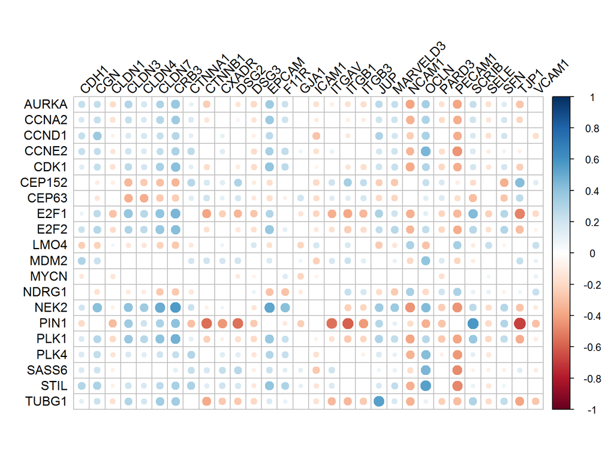

```
##            CA20_group_all_samples
## sample_type Higher Lower
##      Normal      1    60
##      Tumor     230   334
```

## Subtypes Lum A - 625 Samples - Correlation with CA Score

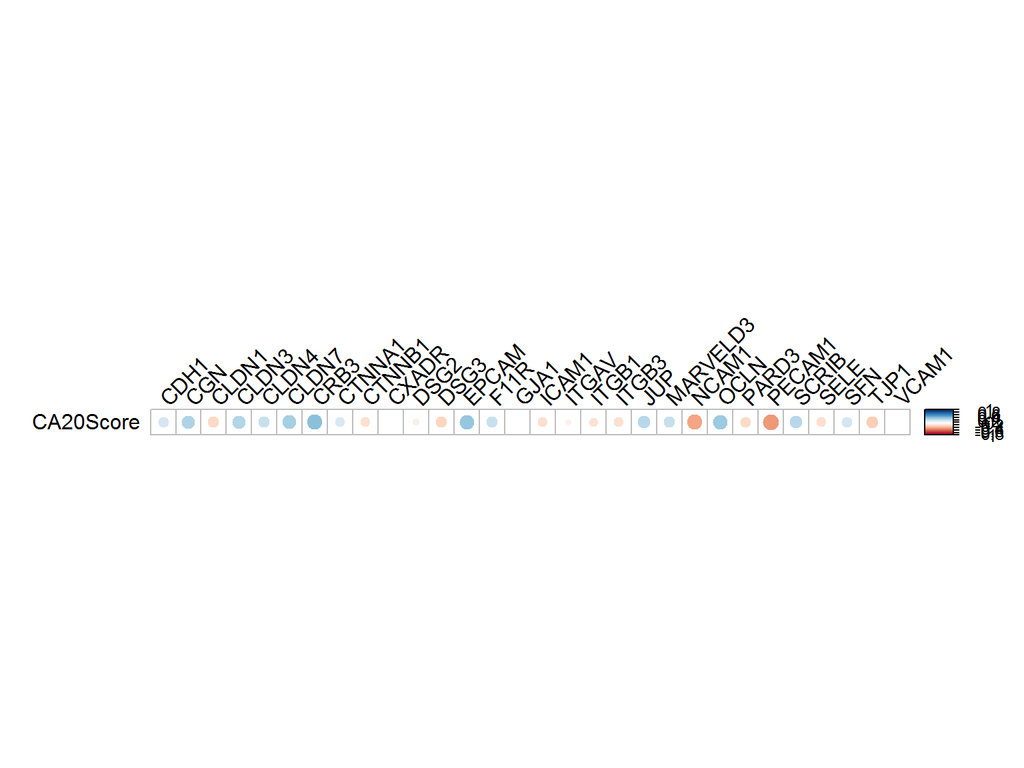

## Subtypes Lum A Correlation Table (CA20Score - CJGenes)

- CJ30 gene expression with CA20 Score of LumA breast cancer patients

  Positive Correlation and Negative Correlation

  |  | Cor | P-val |
  | --- | --- | --- |
  | CRB3 | 0.417 | 0.000 |
  | EPCAM | 0.384 | 0.000 |
  | OCLN | 0.365 | 0.000 |
  | CLDN7 | 0.333 | 0.000 |
  | CGN | 0.306 | 0.000 |
  | CLDN3 | 0.296 | 0.000 |
  | JUP | 0.278 | 0.000 |
  | SCRIB | 0.275 | 0.000 |
  | MARVELD3 | 0.232 | 0.000 |
  | F11R | 0.227 | 0.000 |
  | CLDN4 | 0.222 | 0.000 |
  | SFN | 0.188 | 0.000 |
  | CDH1 | 0.182 | 0.000 |
  | CTNNA1 | 0.169 | 0.000 |
  | CXADR | 0.015 | 0.712 |

  |  | Cor | P-val |
  | --- | --- | --- |
  | PECAM1 | -0.435 | 0.000 |
  | NCAM1 | -0.398 | 0.000 |
  | TJP1 | -0.243 | 0.000 |
  | DSG3 | -0.211 | 0.000 |
  | CLDN1 | -0.209 | 0.000 |
  | PARD3 | -0.199 | 0.000 |
  | ICAM1 | -0.179 | 0.000 |
  | ITGB3 | -0.169 | 0.000 |
  | SELE | -0.165 | 0.000 |
  | CTNNB1 | -0.161 | 0.000 |
  | ITGB1 | -0.153 | 0.000 |
  | DSG2 | -0.087 | 0.029 |
  | ITGAV | -0.074 | 0.066 |
  | VCAM1 | -0.064 | 0.109 |
  | GJA1 | -0.047 | 0.238 |

## De analysis of only lum A patients Tumor and normals

- Now doing DE analyis for lumA breast cancer patients and their matched normals. Due to uneven sample sizes in both groups, the results can be biased.

```
## brca subtype information from:doi.org/10.1016/j.ccell.2018.03.014
```

```
## Batch correction skipped since no factors provided
```

```
## ----------------------- DEA -------------------------------
```

```
## there are Cond1 type LumATumour in  562 samples
```

```
## there are Cond2 type LumANormal in  62 samples
```

```
## there are  9153 features as miRNA or genes
```

```
## I Need about  190 seconds for this DEA. [Processing 30k elements /s]
```

```
## ----------------------- END DEA -------------------------------
```

```
##          mRNA     logFC          FDR      LumA   LumANormal      Delta
## F11R     F11R  4.833262 4.156288e-86 33.637011 1896.8064516 162.576477
## CLDN1   CLDN1 -4.786956 1.612047e-06 45.537367    1.6451613 217.985354
## CTNNA1 CTNNA1  4.728489 2.669457e-60 15.225979  429.7419355  71.995867
## ITGAV   ITGAV -1.734753 4.159270e-08  2.386121    0.6290323   4.139331
```

## Subtypes Lum B - 233 samples only (211 tumor, 22 normal) Cross Correlation

-In luminal B cancer subtypes, 207 out of 211 tumour samples have a higher CA20Score while all 22 Normal samples have a lower CA20Score.

```
## brca subtype information from:doi.org/10.1016/j.ccell.2018.03.014
```

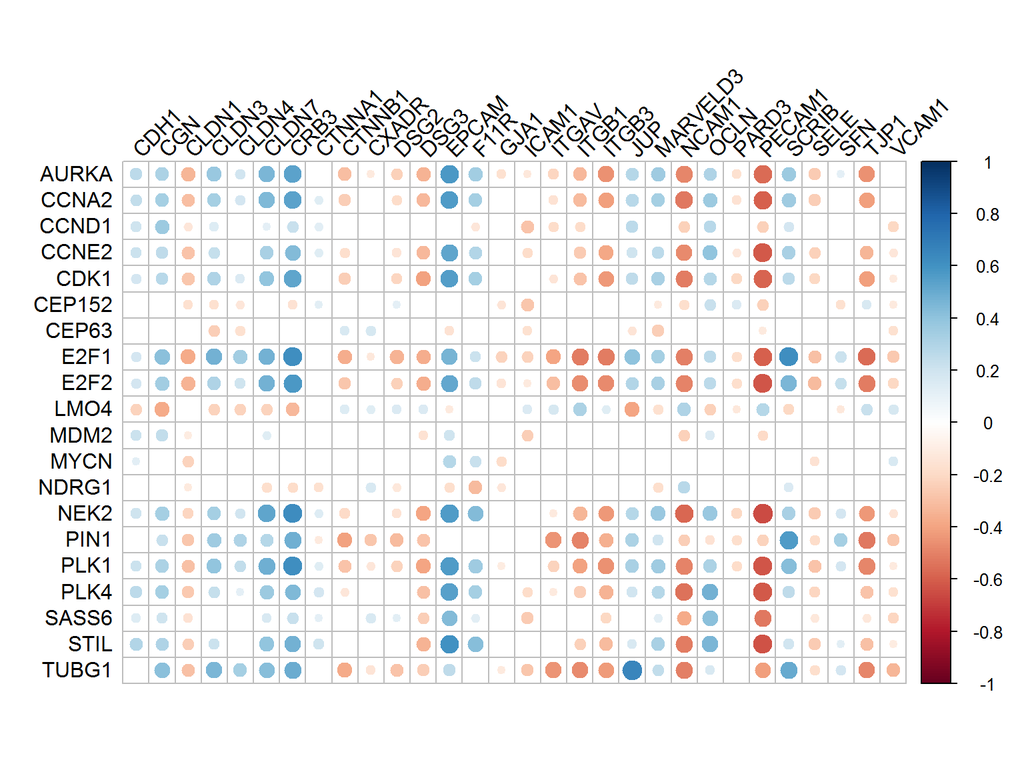

```
##            CA20_group_all_samples
## sample_type Higher Lower
##      Normal      0    22
##      Tumor     207     4
```

## Subtype Lum B - 233 Samples - Correlation with CA Score

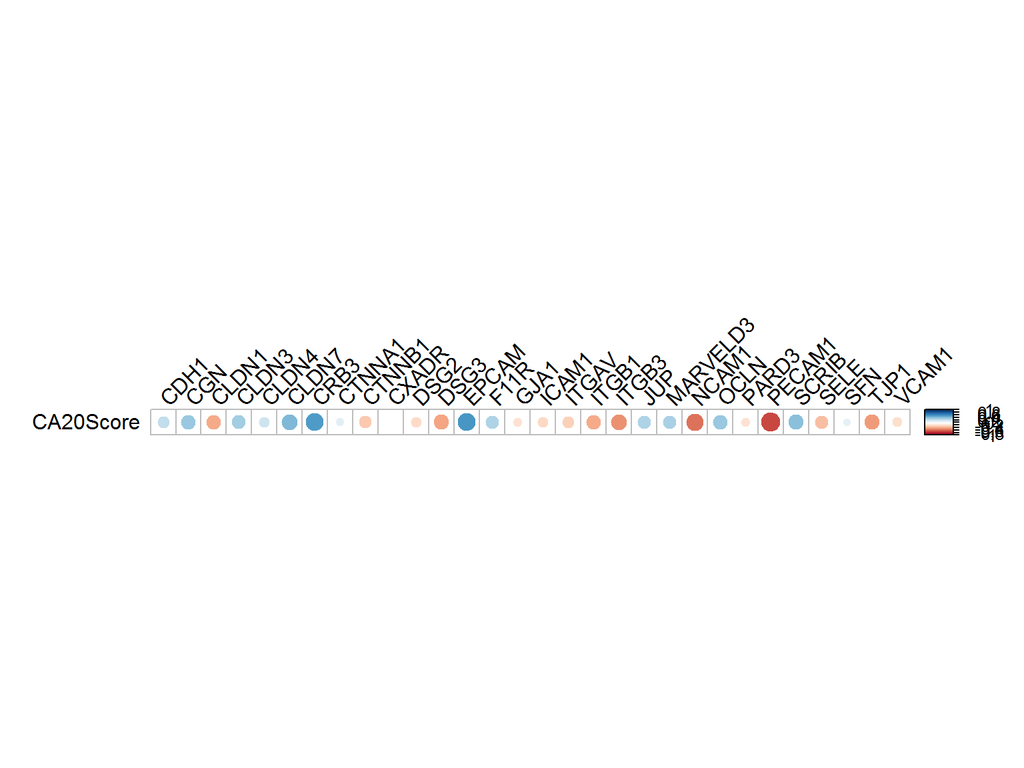

## Subtype Lum B Correlation Table (CA20 Score to CJ Genes)

- CJ30 gene expression with CA20 Score of LuminalB cancer patients.

  Positive Correlation and Negative Correlation

  |  | Cor | P-val |
  | --- | --- | --- |
  | EPCAM | 0.585 | 0.000 |
  | CRB3 | 0.560 | 0.000 |
  | CLDN7 | 0.444 | 0.000 |
  | SCRIB | 0.411 | 0.000 |
  | OCLN | 0.378 | 0.000 |
  | CGN | 0.375 | 0.000 |
  | CLDN3 | 0.342 | 0.000 |
  | MARVELD3 | 0.324 | 0.000 |
  | JUP | 0.310 | 0.000 |
  | F11R | 0.304 | 0.000 |
  | CDH1 | 0.244 | 0.000 |
  | CLDN4 | 0.202 | 0.002 |
  | CTNNA1 | 0.121 | 0.064 |
  | SFN | 0.108 | 0.100 |

  |  | Cor | P-val |
  | --- | --- | --- |
  | PECAM1 | -0.667 | 0.000 |
  | NCAM1 | -0.549 | 0.000 |
  | ITGB3 | -0.450 | 0.000 |
  | TJP1 | -0.428 | 0.000 |
  | DSG3 | -0.399 | 0.000 |
  | CLDN1 | -0.374 | 0.000 |
  | ITGB1 | -0.371 | 0.000 |
  | SELE | -0.301 | 0.000 |
  | CTNNB1 | -0.263 | 0.000 |
  | ITGAV | -0.235 | 0.000 |
  | ICAM1 | -0.201 | 0.002 |
  | DSG2 | -0.198 | 0.002 |
  | VCAM1 | -0.177 | 0.007 |
  | GJA1 | -0.155 | 0.018 |
  | PARD3 | -0.150 | 0.022 |
  | CXADR | -0.067 | 0.311 |

## DE analysis of only lum B patients and matched normals

```
## brca subtype information from:doi.org/10.1016/j.ccell.2018.03.014
```

```
## Batch correction skipped since no factors provided
```

```
## ----------------------- DEA -------------------------------
```

```
## there are Cond1 type LumB-Tumor in  209 samples
```

```
## there are Cond2 type LumB-Normal in  22 samples
```

```
## there are  9153 features as miRNA or genes
```

```
## I Need about  70 seconds for this DEA. [Processing 30k elements /s]
```

```
## ----------------------- END DEA -------------------------------
```

```
##          mRNA     logFC          FDR LumB-Tumor LumB-Normal     Delta
## CLDN1   CLDN1 -7.164716 2.744977e-04 113.665072   0.7272727 814.37792
## CTNNA1 CTNNA1  7.123778 2.940608e-44   2.995215 460.2272727  21.33725
## F11R     F11R  4.167292 4.237895e-19   9.196172 166.7272727  38.32313
## ITGAV   ITGAV -2.255993 1.118030e-03   3.837321   0.7272727   8.65697
## DSG3     DSG3  1.764632 6.511896e-08  18.258373  63.6363636  32.21930
## ITGB3   ITGB3 -1.631001 6.775293e-12 137.023923  44.6818182 223.48611
## ITGB1   ITGB1  1.536929 6.874243e-04  14.114833  43.8636364  21.69349
```

## Subtype Basal - 208 samples, 191 Tumour and 17 Normal samples Cross Correlation

In Basal samples, 188 out of 191 samples have a higher CA20Score while all 17 normal samples have a lower CA20Score.

```
## brca subtype information from:doi.org/10.1016/j.ccell.2018.03.014
```

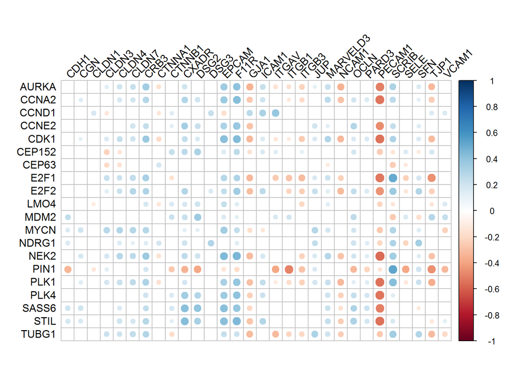

```
##            CA20_group_all_samples
## sample_type Higher Lower
##      Normal      0    17
##      Tumor     188     3
```

## Subtype Basal - 208 samples- Correlation with CA Score

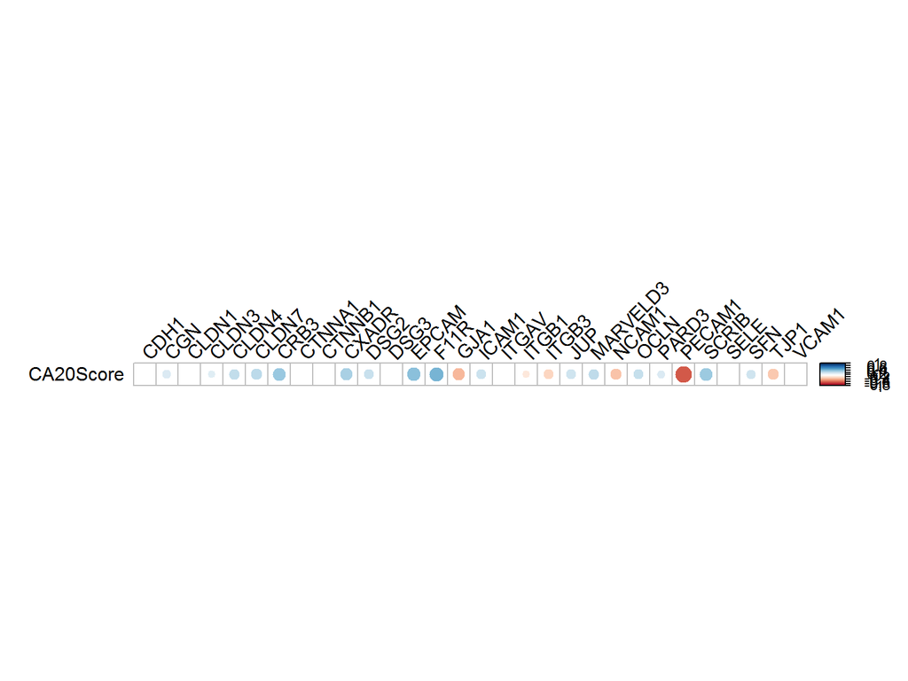

## Subtype Basal Correlation Table (CA20Score - CJ Genes)

- CJ30 gene expression with CA20 Score for basal patient samples

  Positive Correlation and Negative Correlation

  |  | Cor | P-val |
  | --- | --- | --- |
  | F11R | 0.466 | 0.000 |
  | EPCAM | 0.416 | 0.000 |
  | CRB3 | 0.376 | 0.000 |
  | SCRIB | 0.364 | 0.000 |
  | CXADR | 0.328 | 0.000 |
  | CLDN7 | 0.264 | 0.000 |
  | MARVELD3 | 0.258 | 0.000 |
  | CLDN4 | 0.244 | 0.000 |
  | OCLN | 0.231 | 0.001 |
  | DSG2 | 0.222 | 0.001 |
  | ICAM1 | 0.218 | 0.002 |
  | JUP | 0.206 | 0.003 |
  | SFN | 0.205 | 0.003 |
  | CGN | 0.158 | 0.022 |
  | PARD3 | 0.151 | 0.030 |
  | CLDN3 | 0.133 | 0.055 |
  | CDH1 | 0.103 | 0.137 |
  | DSG3 | 0.080 | 0.250 |
  | CTNNB1 | 0.034 | 0.627 |
  | CLDN1 | 0.028 | 0.684 |

  |  | Cor | P-val |
  | --- | --- | --- |
  | PECAM1 | -0.614 | 0.000 |
  | GJA1 | -0.327 | 0.000 |
  | NCAM1 | -0.287 | 0.000 |
  | TJP1 | -0.265 | 0.000 |
  | ITGB3 | -0.217 | 0.002 |
  | ITGB1 | -0.124 | 0.074 |
  | SELE | -0.107 | 0.125 |
  | CTNNA1 | -0.106 | 0.129 |
  | ITGAV | -0.076 | 0.277 |
  | VCAM1 | -0.021 | 0.765 |

## De analysis of only Basal patients and matched normals

```
## brca subtype information from:doi.org/10.1016/j.ccell.2018.03.014
```

```
## Batch correction skipped since no factors provided
```

```
## ----------------------- DEA -------------------------------
```

```
## there are Cond1 type Basal-Tumor in  190 samples
```

```
## there are Cond2 type Basal-Normal in  17 samples
```

```
## there are  9153 features as miRNA or genes
```

```
## I Need about  63 seconds for this DEA. [Processing 30k elements /s]
```

```
## ----------------------- END DEA -------------------------------
```

```
##          mRNA    logFC          FDR Basal-Tumor Basal-Normal    Delta
## CTNNA1 CTNNA1 6.487126 9.563903e-24    4.736842    402.76471 30.72849
## ITGB1   ITGB1 3.126844 2.832554e-13    4.326316     39.17647 13.52772
```

## Subtypes Her2 - 91 samples, 82 tumor and 9 normal samples - Cross Correlation

- In Her2 BRCA Subtype, all 9 normal samples have a lower CA20Score while 79 out of 82 tumour samples have a high CA20Score.

```
## brca subtype information from:doi.org/10.1016/j.ccell.2018.03.014
```

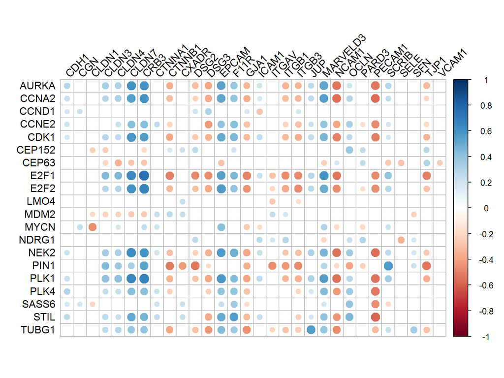

```
##            CA20_group_all_samples
## sample_type Higher Lower
##      Normal      0     9
##      Tumor      79     3
```

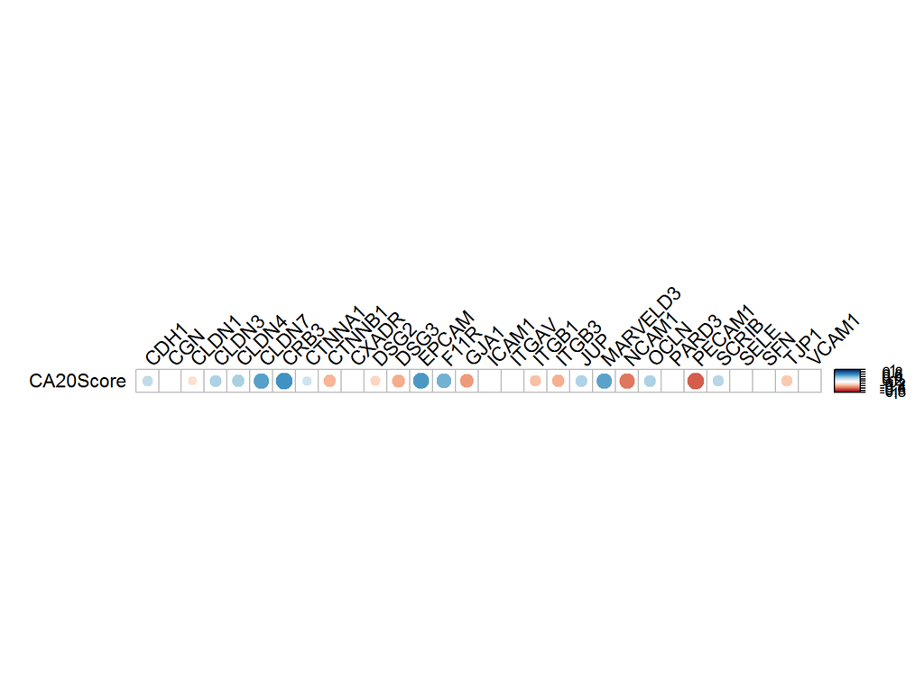

## Subtype Her2 Correlation Table (CA20Score - CJGenes)

- CJ30 gene expression with CA20 Score of HER2 subtype

  Positive Correlation and Negative Correlation

  |  | Cor | P-val |
  | --- | --- | --- |
  | CRB3 | 0.610 | 0.000 |
  | EPCAM | 0.577 | 0.000 |
  | CLDN7 | 0.547 | 0.000 |
  | MARVELD3 | 0.536 | 0.000 |
  | F11R | 0.479 | 0.000 |
  | CLDN4 | 0.327 | 0.002 |
  | CLDN3 | 0.319 | 0.002 |
  | OCLN | 0.310 | 0.003 |
  | JUP | 0.302 | 0.004 |
  | SCRIB | 0.285 | 0.006 |
  | CDH1 | 0.251 | 0.016 |
  | CTNNA1 | 0.203 | 0.053 |
  | SFN | 0.171 | 0.105 |
  | ICAM1 | 0.165 | 0.118 |
  | SELE | 0.087 | 0.414 |
  | CGN | 0.074 | 0.485 |
  | CXADR | 0.021 | 0.844 |

  |  | Cor | P-val |
  | --- | --- | --- |
  | PECAM1 | -0.607 | 0.000 |
  | NCAM1 | -0.526 | 0.000 |
  | GJA1 | -0.430 | 0.000 |
  | DSG3 | -0.367 | 0.000 |
  | ITGB3 | -0.355 | 0.001 |
  | CTNNB1 | -0.334 | 0.001 |
  | ITGB1 | -0.293 | 0.005 |
  | TJP1 | -0.263 | 0.012 |
  | DSG2 | -0.210 | 0.045 |
  | CLDN1 | -0.177 | 0.093 |
  | VCAM1 | -0.146 | 0.167 |
  | PARD3 | -0.121 | 0.254 |
  | ITGAV | -0.110 | 0.301 |

## De analysis of Her2 patients and matched normals

```
## brca subtype information from:doi.org/10.1016/j.ccell.2018.03.014
```

```
## Batch correction skipped since no factors provided
```

```
## ----------------------- DEA -------------------------------
```

```
## there are Cond1 type her2-Tumor in  82 samples
```

```
## there are Cond2 type her2-Normal in  9 samples
```

```
## there are  9153 features as miRNA or genes
```

```
## I Need about  28 seconds for this DEA. [Processing 30k elements /s]
```

```
## ----------------------- END DEA -------------------------------
```

```
##          mRNA     logFC          FDR her2-Tumor her2-Normal    Delta
## CTNNA1 CTNNA1  7.092770 4.157707e-28   3.292683 445.1111111 23.35424
## F11R     F11R  4.576376 4.217989e-14   5.439024 123.0000000 24.89102
## ITGAV   ITGAV -3.788574 1.355854e-03  13.024390   0.7777778 49.34387
## ITGB1   ITGB1  2.854258 1.536505e-07   7.365854  52.4444444 21.02405
```